# LESSON 4: GRADIENT DESCENT - OPTIMIZATION ALGORITHMS

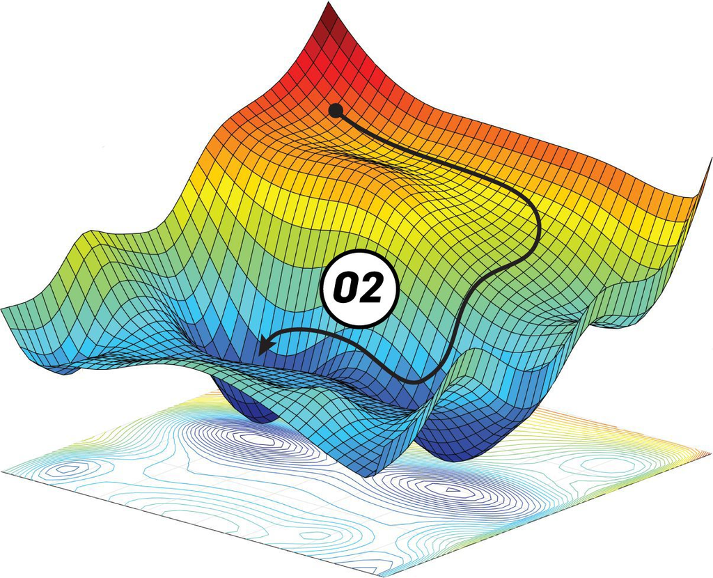

*This lecture was refered by [machinelearningcoban.com](https://machinelearningcoban.com/2017/01/12/gradientdescent/)*

## 1. Gradient descent introduction

In machine learning, we usually have to find the optimal point of a function (minimum or maximum).

For example: finding minimum of MSE loss function of Linear regression ...

In calculus, we split minimum point into 2 types: Local minimum and Global minimum

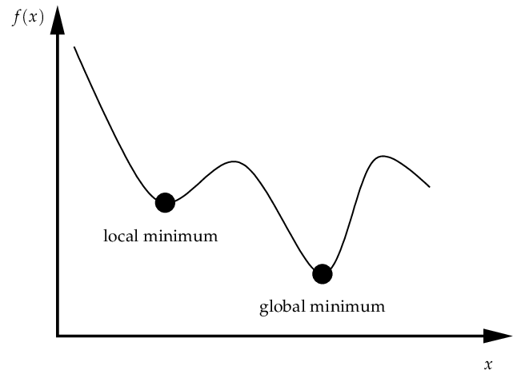

In theory, we can solve derivative equation to find all of local minimum points and choose the smallest to find global minimum point.

But, in reality, it's too hard (or maybe impossible) to solve the derivative equation because of the large-scale dataset, the complexity of the derivative equation or the high-dimension data points etc.

That's why we need to build an algorithm to gradually archieve local minimum point instead of finding it directly.

*GRADIENT DESCENT* solved the problem and become the most important part in lots of machine learning algorithms and deep learning models till now.

## 2. Gradient descent for singlevariate function

### 2.1. Formula

We have a simple singlevariate function and $x^*$ is an minimum point.

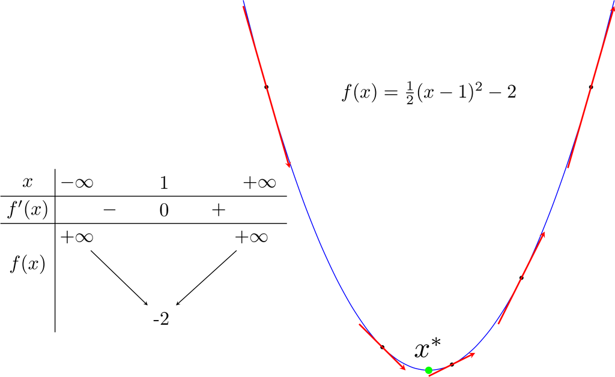

Assume that we have $x_t$ in the *t* iteration of gradient descent algorithm, our mission is to bring $x_t$ near to $x^*$.

If $f'(x_t) > 0$, so $x_t > x^*$ and if $f'(x_t) < 0$, so $x_t < x^*$.

We have $x_{t+1} = x_t + \delta$ which delta has different sign of $f'(x_t)$ (if $f'(x_t) > 0$, so $\delta < 0$ and vice versa).

The larger distance between $x_t$ and $x^*$, the higher value of $|f'(x_t)|$. So, $\delta = - \eta f'(x_t)$ and $x_{t+1} = x_t - \eta f'(x_t)$.

$\eta$ is call *learning rate* which is really important in optimization. And the sign - is the reason why we call this algorithm *Gradient descent*.

### 2.2. Implementation

We have an example:

\[ f(x) = x^2 + 5 \sin(x) \\ f'(x) = 2x + 5 \cos(x) \\ x_{t+1} = x_t - \eta (2x + 5 \cos(x)) \]

```python
import numpy as np
```

```python
def my_function(x):
    return x ** 2 + 5 * np.sin(x)
```

```python
def my_grad(x):
    return 2 * x + 5 * np.cos(x)
```

```python
def my_gradient_descent(lr, x_0):
    x = [x_0]
    for it in range(100):
        x_new = x[-1] - lr * my_grad(x[-1])
        if abs(my_grad(x_new)) < 1e-3:
            break
        x.append(x_new)
    return (x, it)
```

```python
(solution_1, iteration_1) = my_gradient_descent(lr=.1, x_0=-5)
(solution_1, iteration_1)
```

```
([-5,
  -4.141831092731613,
  -3.0434140487394945,
  -1.9371390635788721,
  -1.370609623535342,
  -1.1959138533062952,
  -1.1398126662660861,
  -1.1207324901805855,
  -1.1140974995041208,
  -1.1117718342401366,
  -1.1109543623859697,
  -1.1106667365268623],
 11)
```

```python
(solution_2, iteration_2) = my_gradient_descent(lr=.1, x_0=5)
(solution_2, iteration_2)
```

```
([5,
  3.8581689072683867,
  3.463564567930569,
  3.2451582916682646,
  3.0934475688734215,
  2.9741786797296776,
  2.8723524342019475,
  2.7798685851337033,
  2.691538912182054,
  2.6034429924417726,
  2.512083663118539,
  2.413825273788166,
  2.3043909242955314,
  2.178284700900974,
  2.028031263811057,
  1.8431593967550366,
  1.6090315913519224,
  1.3063382475764564,
  0.9143774850440367,
  0.42636006838025553,
  -0.11415049832376267,
  -0.5880663503407275,
  -0.8864605464168875,
  -1.025247680965368,
  -1.0796417320111382,
  -1.0995355411928176,
  -1.1066334337506414,
  -1.1091439570842945,
  -1.1100292207856688,
  -1.1103410483948122],
 29)
```

```python
my_function(solution_1[-1])
```

```
-3.2463941936103735
```

```python
my_function(solution_2[-1])
```

```
-3.246394179661889
```

#### Compare initialization

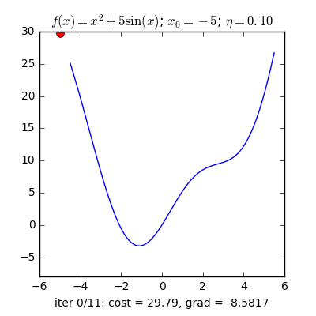

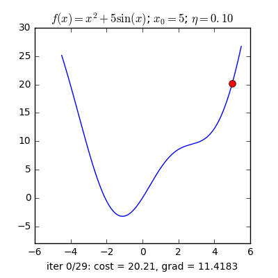

With initialization $x_0 = -5$, the solution is converged much faster than initialization $x_0 = 5$.

#### Compare learning rate

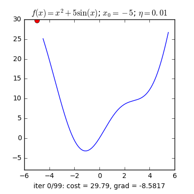

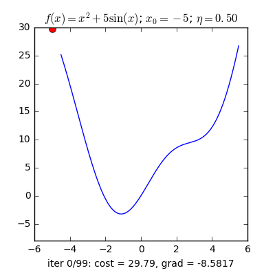

With learning rate $\eta = 0.01$, the solution is converged too slow (almost 10 times compare with learning rate $\eta = 0.1$)

## 3. Gradient descent for multivariate function

### 3.1. Formula

One example of multivariate function is Linear regression.

The loss function of Linear regression,

\[ MSE(w) = \frac{1}{N}\frac{1}{2}(Xw - y)^2 \]

and the derivative of the loss function,

\[ \frac{\partial MSE}{\partial w} = \frac{1}{N}{X}^{T}\cdot(Xw - y) \]

### 3.2. Implementation

#### Prepare linear regression data and model

```python
import pandas as pd
from sklearn.linear_model import LinearRegression
```

```python
df = pd.read_csv('../data/linear_regression_salary_data.csv')

X = np.array([df.YearsExperience.to_list()])
y = np.array([df.Salary.to_list()])
```

```python
def prepare_X_ones(X):
    x_1 = np.ones_like(X)
    print('x_0.shape', x_1.shape)

    X = np.concatenate((x_1, X), axis=0).T
    print('X.shape', X.shape)

    return X
```

```python
X_with_1 = prepare_X_ones(X)
```

```
x_0.shape (1, 30)
X.shape (30, 2)
```

```python
sklearn_linear_regression = LinearRegression(fit_intercept=False)
sklearn_linear_regression.fit(X_with_1, y.T)
sklearn_linear_regression.coef_
```

```
array([[25792.20019867,  9449.96232146]])
```

#### Implement gradient descent

```python
def my_mse(w, X, y):
    N = X.shape[0]
    return (1/ N) * (1 / 2) * np.linalg.norm(y - X.dot(w), 2) ** 2;
```

```python
def my_mse_grad(w, X, y):
    N = X.shape[0]
    return 1 / N * X.T.dot(X.dot(w) - y)
```

```python
def my_mse_gradient_descent(lr, w_init, X, y):
    w = [w_init]
    for it in range(2000):
        w_new = w[-1] - lr * my_mse_grad(w[-1], X, y)
        if np.linalg.norm(my_mse_grad(w_new, X, y)) / len(w_new) < 1e-3:
            break
        w.append(w_new)
    return (w, it)
```

```python
w_init = np.array([[2], [1]])
```

```python
(solution_w_1, iteration_1) = my_mse_gradient_descent(0.05, w_init, X_with_1, y.T)
```

```python
solution_w_1[-1]
```

```
array([[25792.19080029],
       [ 9449.96371613]])
```

```python
iteration_1
```

```
1387
```

```python
sklearn_linear_regression.coef_
```

```
array([[25792.20019867,  9449.96232146]])
```